# Lab 2 - Classification

Tran Cong Tuan Manh

2022/03/08

## Câu hỏi 1

Trong bài hướng dẫn, ta đã áp dụng `random forest` trên tập dữ liệu `Boston` dùng `mtry=6` và `ntree=25`, `ntree=500`. Bây giờ, bạn hãy tạo một biểu đồ (tương tự như trong slide 21) mô tả `test error` của `random forest`trên tập dữ liệu này theo `mtry` và `ntree` dùng một miền giá trị cho `mtry` và `ntree`. Mô tả kết quả thu được.

```r
# Viết mã R của bạn ở đây
library(randomForest)
library(MASS)
data(Boston)
attach(Boston)
dim(Boston)
```

```
## [1] 506  14
```

```r
set.seed(134)
# Tạo tập train và test
train <- sample(1:nrow(Boston), nrow(Boston)/3)

x.train <- Boston[train, -14]
y.train <- Boston[train, 14]
x.test <- Boston[-train, -14]
y.test <- Boston[-train, 14]
```

```r
# Tạo cây với mtry=6 và ntree= 25 & 500
rf.1 <- randomForest(x=x.train, y=y.train, xtest=x.test, ytest=y.test, mtry=6, ntree=25)
rf.2 <- randomForest(x=x.train, y=y.train, xtest=x.test, ytest=y.test, mtry=6, ntree=500)
```

```r
which.min(rf.1$test$mse)
```

```
## [1] 23
```

```r
which.min(rf.2$test$mse)
```

```
## [1] 279
```

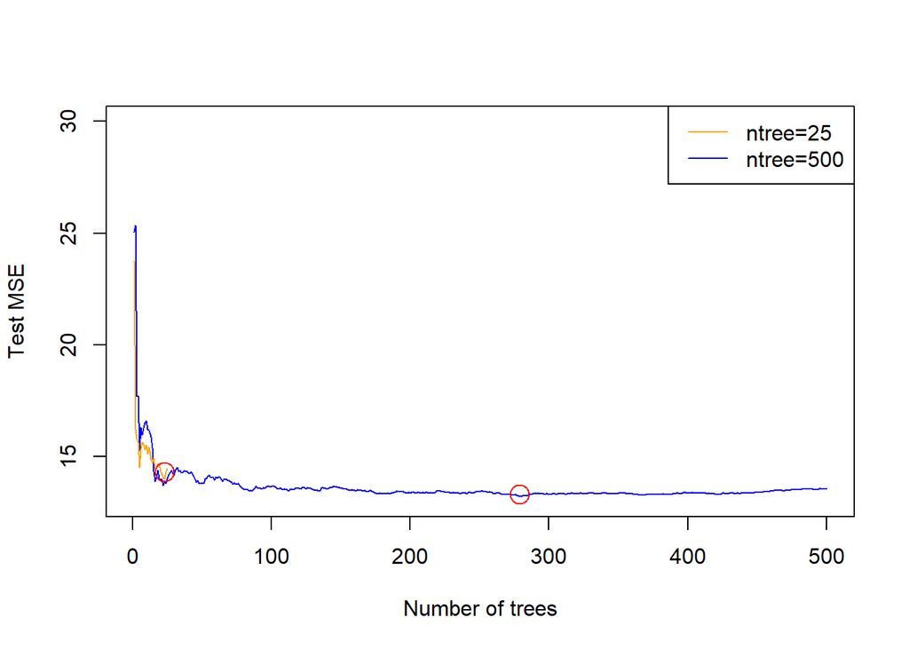

```r
plot(1:500, rf.2$test$mse, type='l', col='blue', xlab="Number of trees", ylab = "Test MSE", ylim=c(13, 30))
lines(1:25, rf.1$test$mse, type='l', col="orange")
legend("topright", legend=c("ntree=25", "ntree=500"), col=c("orange", "blue"), lty=1, cex=1)
points(which.min(rf.1$test$mse), rf.1$test$mse[24], col="red", cex=2)
points(which.min(rf.2$test$mse), rf.2$test$mse[362], col="red", cex=2)
```

## Câu hỏi 2

Trong bài hướng dẫn, ta đã tạo một `classiﬁcation tree` trên tập dữ liệu `Carseats` sau khi chuyển biến `Sales` thành biến categorical là `High`. Bây giờ, bạn hãy dự đoán biến `Sales` dùng `regression tree`, xem biến này là biến numeric.

1. Chia dữ thành `training set` và `test set`.

```r
# Viết mã R của bạn ở đây
library(tree)
library(ISLR2)
attach(Carseats)
```

```r
set.seed(456)
train <- sample(1:nrow(Carseats), nrow(Carseats)/3)
Carseats.train <- Carseats[train, ]
Carseats.test <- Carseats[-train, ]
y.test <- Carseats.test$Sales
```

2. Fit một `regression tree` trên `training set`. Vẽ tree thu được và diễn giải kết quả. Cho biết `test MSE` là bao nhiêu?

```r
# Viết mã R của bạn ở đây
carseats.tree <- tree(Sales ~ ., data=Carseats.train)
summary(carseats.tree)
```

```
##
## Regression tree:
## tree(formula = Sales ~ ., data = Carseats.train)
## Variables actually used in tree construction:
## [1] "ShelveLoc"   "Price"       "Age"         "CompPrice"   "Advertising"
## Number of terminal nodes:  14
## Residual mean deviance:  1.822 = 216.9 / 119
## Distribution of residuals:
##    Min. 1st Qu.  Median    Mean 3rd Qu.    Max.
## -3.9700 -0.7836 -0.0300  0.0000  0.8100  4.1040
```

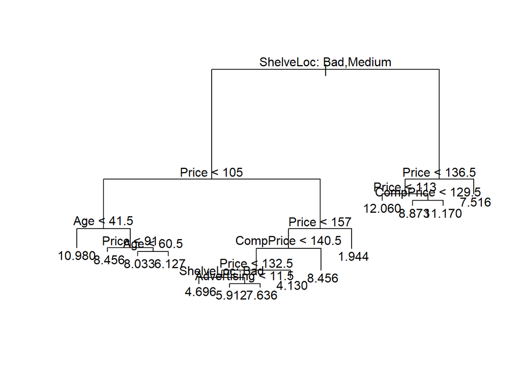

```r
plot(carseats.tree)
text(carseats.tree, pretty=0)
```

```r
carseats.tree
```

```
## node), split, n, deviance, yval
##       * denotes terminal node
##
##   1) root 133 1153.000  7.300
##     2) ShelveLoc: Bad,Medium 103  617.900  6.389
##       4) Price < 105 33  136.200  8.267
##         8) Age < 41.5 7    8.203 10.980 *
##         9) Age > 41.5 26   62.500  7.536
##          18) Price < 91 10    6.412  8.456 *
##          19) Price > 91 16   42.320  6.961
##            38) Age < 60.5 7    9.708  8.033 *
##            39) Age > 60.5 9   18.310  6.127 *
##       5) Price > 105 70  310.600  5.504
##        10) Price < 157 65  220.000  5.778
##          20) CompPrice < 140.5 56  133.300  5.348
##            40) Price < 132.5 43   83.130  5.716
##              80) ShelveLoc: Bad 14   19.350  4.696 *
##              81) ShelveLoc: Medium 29   42.170  6.209
##               162) Advertising < 11.5 24   26.090  5.912 *
##               163) Advertising > 11.5 5    3.777  7.636 *
##            41) Price > 132.5 13   25.040  4.130 *
##          21) CompPrice > 140.5 9   11.810  8.456 *
##        11) Price > 157 5   22.380  1.944 *
##     3) ShelveLoc: Good 30  156.500 10.430
##       6) Price < 136.5 25   79.880 11.010
##        12) Price < 113 11    6.500 12.060 *
##        13) Price > 113 14   51.610 10.180
##          26) CompPrice < 129.5 6   16.500  8.873 *
##          27) CompPrice > 129.5 8   17.080 11.170 *
##       7) Price > 136.5 5   25.730  7.516 *
```

```r
#Test MSE
ypredict <- predict(carseats.tree, newdata=Carseats.test)
mean((ypredict - y.test)^2)
```

```
## [1] 4.932082
```

3. Sử dụng `cross-validation` để xác định mức độ phức tạp tối ưu của cây. Việc `pruning` (cắt tỉa cây) có cải thiện `test MSE` không?

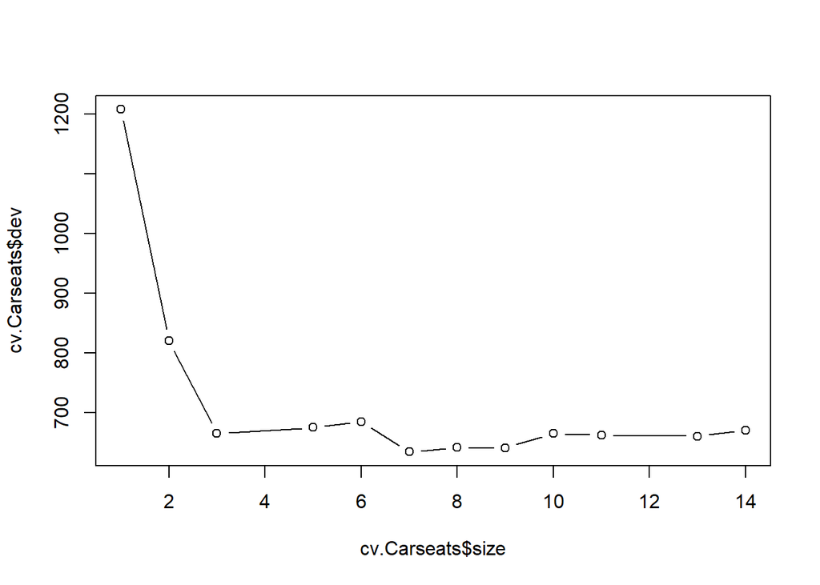

```r
# Viết mã R của bạn ở đây
cv.Carseats <- cv.tree(carseats.tree)
plot(cv.Carseats$size, cv.Carseats$dev, type='b')
```

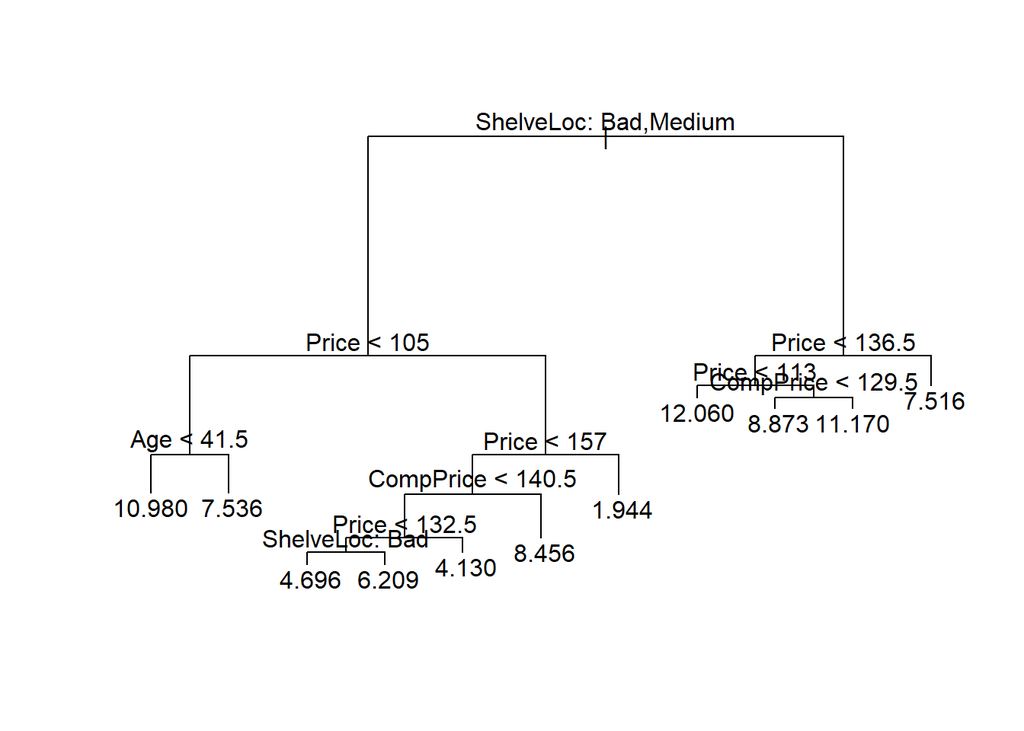

```r
prune.Carseats <- prune.tree(carseats.tree, best=11)
plot(prune.Carseats)
text(prune.Carseats, pretty=0)
```

```r
ypredict <- predict(prune.Carseats, Carseats.test)
mean((ypredict-y.test)^2)
```

```
## [1] 5.442168
```

Kết luận: Việc cắt tỉa cây khiến test MSE cao hơn.

4. Sử dụng `bagging` để phân tích tập dữ liệu này. Cho biết `test MSE` thu được là bao nhiêu? Sử dụng hàm `importance()` để xác định biến quan trọng nhất.

```r
# Viết mã R của bạn ở đây
require(randomForest)
bag.Carseats <- randomForest(Sales ~., data=Carseats.train, mtry=10, importance=TRUE)
```

```r
ypredict.bag <- predict(bag.Carseats, newdata=Carseats.test)
mean((ypredict.bag-y.test)^2)
```

```
## [1] 3.202381
```

“bagging” giảm test MSE xuống còn 3.2

```r
importance(bag.Carseats)
```

```
##                %IncMSE IncNodePurity
## CompPrice   19.8407700    101.946673
## Income       1.5776638     34.098574
## Advertising 10.0273737     52.710840
## Population   0.9183100     37.500279
## Price       48.3631891    368.415423
## ShelveLoc   53.8051100    398.823573
## Age         22.4095450     94.515766
## Education   -3.9507758     13.962131
## Urban        0.4736674      5.104565
## US           1.0233979      5.039576
```

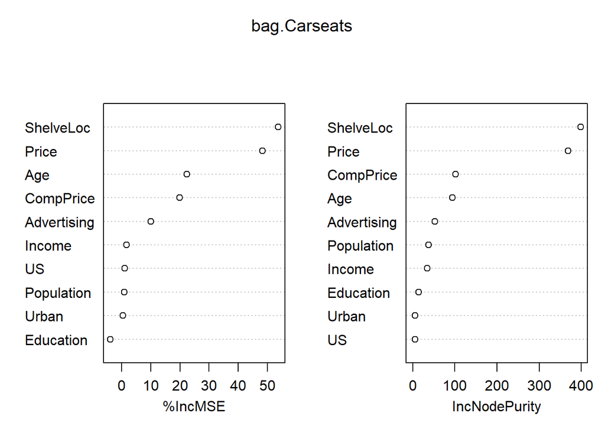

```r
varImpPlot(bag.Carseats)
```

Kết luận: Có hai biến quan trọng nhất là Price và ShelveLoc.

5. Sử dụng `random forest` để phân tích tập dữ liệu này. Cho biết `test MSE` thu được là bao nhiêu? Sử dụng hàm `importance()` để xác định biến quan trọng nhất. Mô tả hiệu quả của `m`, số biến được xem xét để tách, trên `error rate` thu được.

```r
# Viết mã R của bạn ở đây
rf.Carseats <- randomForest(Sales~., data=Carseats.train, mtry=floor((ncol(Carseats)-1)/3),importance=TRUE)
```

```r
ypredict.rf <- predict(rf.Carseats, newdata = Carseats.test)
mean((ypredict.rf-y.test)^2)
```

```
## [1] 3.182398
```

```r
importance(rf.Carseats)
```

```
##                  %IncMSE IncNodePurity
## CompPrice    7.194247312     103.62388
## Income      -0.008829796      69.81054
## Advertising  7.801325330      86.20758
## Population  -0.282124699      72.39351
## Price       28.708280237     266.52490
## ShelveLoc   33.418988917     290.62578
## Age          9.200690281     137.60930
## Education   -1.743904879      42.12174
## Urban       -0.150702432      11.20534
## US           2.468672669      13.24239
```

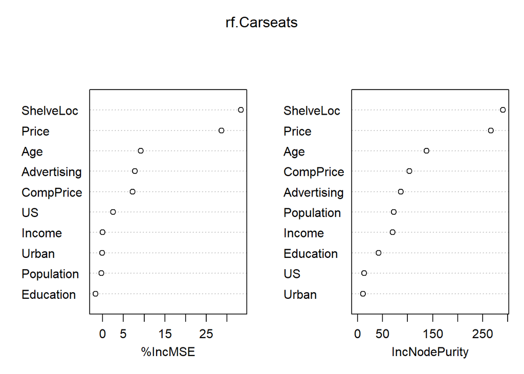

```r
varImpPlot(rf.Carseats)
```

Kết luận: biến quan trọng nhất là Price và ShelveLoc.

## Câu hỏi 3

Câu hỏi này liên quan đến tập dữ liệu `OJ` của thư viện `ISLR`.

1. Tạo một `training set` chứa một mẫu ngẫu nhiên gồm 800 điểm dữ liệu, và một `test set` chứa các điểm dữ liệu còn lại.

```r
# Viết mã R của bạn ở đây
require(ISLR)
data(OJ)
attach(OJ)
set.seed(87)
train_3a <- sample(1:nrow(OJ), 800)
train_OJ <- OJ[train_3a, ]
test_OJ <- OJ[-train_3a, ]
```

2. Fit một tree trên `training data`, với `Purchase` là output và các biến khác là input. Sử dụng hàm `summary()` để tạo một `summary statistics` về cây thu được. Mô tả kết quả thu được. Cho biết `training error rate` là bao nhiêu? Cây có bao nhiêu `terminal node`?

```r
# Viết mã R của bạn ở đây
require(tree)
tree_OJ <- tree(Purchase ~., data=train_OJ) # There's no variable "Buy" in this dataset
summary(tree_OJ)
```

```
##
## Classification tree:
## tree(formula = Purchase ~ ., data = train_OJ)
## Variables actually used in tree construction:
## [1] "LoyalCH"       "SalePriceMM"   "PriceDiff"     "DiscMM"
## [5] "ListPriceDiff"
## Number of terminal nodes:  9
## Residual mean deviance:  0.712 = 563.2 / 791
## Misclassification error rate: 0.1538 = 123 / 800
```

Traning error: 0.1538.  
Có 9 terminal nodes.

3. Liệt kê chi tiết về output của cây bằng cách dùng tên của `tree object`. Chọn một `terminal node` và giải thích thông tin nó thể hiện.

```r
# Viết mã R của bạn ở đây
tree_OJ
```

```
## node), split, n, deviance, yval, (yprob)
##       * denotes terminal node
##
##  1) root 800 1075.00 CH ( 0.60250 0.39750 )
##    2) LoyalCH < 0.482304 300  305.70 MM ( 0.20667 0.79333 )
##      4) LoyalCH < 0.0356415 57    0.00 MM ( 0.00000 1.00000 ) *
##      5) LoyalCH > 0.0356415 243  276.00 MM ( 0.25514 0.74486 )
##       10) SalePriceMM < 2.04 130  108.20 MM ( 0.14615 0.85385 ) *
##       11) SalePriceMM > 2.04 113  150.10 MM ( 0.38053 0.61947 )
##         22) LoyalCH < 0.277977 53   54.13 MM ( 0.20755 0.79245 ) *
##         23) LoyalCH > 0.277977 60   82.91 CH ( 0.53333 0.46667 ) *
##    3) LoyalCH > 0.482304 500  439.70 CH ( 0.84000 0.16000 )
##      6) LoyalCH < 0.764572 245  291.30 CH ( 0.71837 0.28163 )
##       12) PriceDiff < 0.015 79  108.90 MM ( 0.45570 0.54430 )
##         24) DiscMM < 0.47 60   82.11 CH ( 0.56667 0.43333 ) *
##         25) DiscMM > 0.47 19   12.79 MM ( 0.10526 0.89474 ) *
##       13) PriceDiff > 0.015 166  144.10 CH ( 0.84337 0.15663 )
##         26) ListPriceDiff < 0.255 71   82.48 CH ( 0.73239 0.26761 ) *
##         27) ListPriceDiff > 0.255 95   49.98 CH ( 0.92632 0.07368 ) *
##      7) LoyalCH > 0.764572 255   90.67 CH ( 0.95686 0.04314 ) *
```

4. Tạo một biểu đồ của cây và giải thích kết quả.

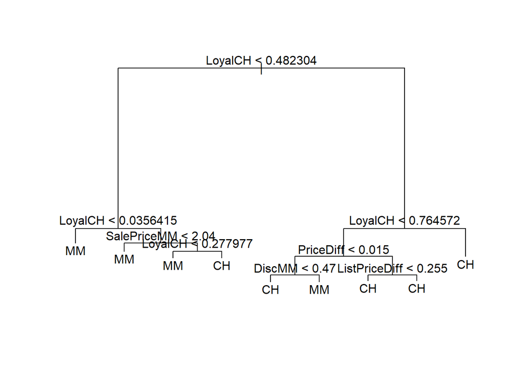

```r
# Viết mã R của bạn ở đây
plot(tree_OJ)
text(tree_OJ, pretty=0)
```

5. Dự đoán output trên `test set` và tạo một `confusion matrix` để so sánh `actual test labels` với `predicted test labels`. Cho biết `test error rate`?

```r
# Viết mã R của bạn ở đây
y_test_OJ <- test_OJ$Purchase

tree_pred <- predict(tree_OJ, test_OJ, type="class")
table(tree_pred, y_test_OJ)
```

```
##          y_test_OJ
## tree_pred  CH  MM
##        CH 150  37
##        MM  21  62
```

```r
testerror <- (21 + 37)/(150 + 37 + 21 + 62)
print(testerror)
```

```
## [1] 0.2148148
```

Test error: 21.48%.

6. Áp dụng hàm `cv.tree()` trên `training set` để xác định `optimal tree size`.

```r
# Viết mã R của bạn ở đây
cv_tree <- cv.tree(tree_OJ, FUN=prune.misclass)
cv_tree
```

```
## $size
## [1] 9 8 5 2 1
##
## $dev
## [1] 129 129 135 142 318
##
## $k
## [1]       -Inf   0.000000   1.333333   5.000000 176.000000
##
## $method
## [1] "misclass"
##
## attr(,"class")
## [1] "prune"         "tree.sequence"
```

7. Tạo một biểu đồ với `tree size` trên `x-axis` và `cross-validated classiﬁcation error rate` trên `y-axis`.

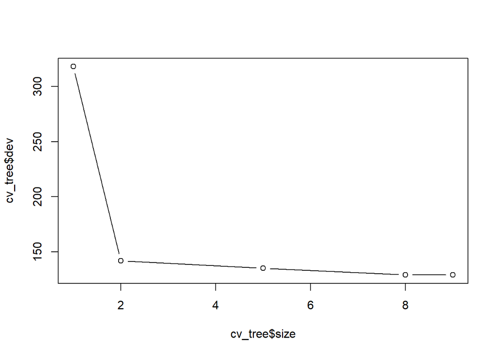

```r
# Viết mã R của bạn ở đây
plot(cv_tree$size, cv_tree$dev, type='b')
```

8. Cho biết `tree size` nào tương ứng với `cross-validated classiﬁcation error rate` nhỏ nhất?

1. Tạo một `pruned tree` tương ứng với `optimal tree size` dùng `cross-validation`. Nếu `cross-validation` không cho ra kết quả là một `pruned tree` thì tạo một `pruned tree` với 5 `terminal nodes`.

```r
# Viết mã R của bạn ở đây
prune_OJ <- prune.misclass(tree_OJ, best=5)
summary(prune_OJ)
```

```
##
## Classification tree:
## snip.tree(tree = tree_OJ, nodes = c(13L, 2L))
## Variables actually used in tree construction:
## [1] "LoyalCH"   "PriceDiff" "DiscMM"
## Number of terminal nodes:  5
## Residual mean deviance:  0.7992 = 635.4 / 795
## Misclassification error rate: 0.1588 = 127 / 800
```

trainning errow ở cây mới là 15.88%.

10. So sánh `training error rate` giữa `pruned tree` và `unpruned tree`. Cây nào cho kết quả tốt hơn?

`training error rate` cây dùng `pruned tree`(15.88%) cho kết quả không tốt bằng `unpruned tree`(15.38%).

11. So sánh `test error rate` giữa `pruned tree` và `unpruned tree`. Cây nào cho kết quả tốt hơn?

```r
# Viết mã R của bạn ở đây
prune_predict <- predict(prune_OJ, test_OJ, type = "class")
table(prune_predict, y_test_OJ)
```

```
##              y_test_OJ
## prune_predict  CH  MM
##            CH 138  29
##            MM  33  70
```

```r
testerror <- (33 + 29)/(138 + 70 + 33 + 29)
print(testerror)
```

```
## [1] 0.2296296
```

Test error: 22.96%.  
`unpruned tree` cho kết quả tốt hơn với test error là 21.48%.

## Câu hỏi 4

Ta sẽ sử dụng `boosting` để sự đoán `Salary` trong tập dữ liệu `Hitters`.

```r
require(ISLR)
data(Hitters)
attach(Hitters)
```

1. Loại bỏ những dòng trong tập dữ liệu mà giá trị `Salary` là không có hoặc không biết, sau đó lấy `log` của `Salary`.

```r
# Viết mã R của bạn ở đây
summary(Hitters$Salary)
```

```
##    Min. 1st Qu.  Median    Mean 3rd Qu.    Max.    NA's
##    67.5   190.0   425.0   535.9   750.0  2460.0      59
```

```r
Hitters <- na.omit(Hitters)
summary(Hitters$Salary)
```

```
##    Min. 1st Qu.  Median    Mean 3rd Qu.    Max.
##    67.5   190.0   425.0   535.9   750.0  2460.0
```

```r
Hitters$Salary <- log(Hitters$Salary)
```

2. Tạo một `training set` gồm 200 điểm dữ liệu đầu tiên và `test set` là các điểm dữ liệu còn lại trong tập dữ liệu.

```r
nrow(Hitters)
```

```
## [1] 263
```

```r
# Viết mã R của bạn ở đây
train_Hit <- Hitters[1:200, ]
test_Hit <- Hitters[201:263, ]
```

3. Thực hiện `boosting` trên `training set` với `1,000 trees` dùng một dãy các giá trị cho tham số $\lambda$ (`shrinkage parameter`). Tạo một biểu đồ với `x-axis` là các giá trị $\lambda$ khác nhau và `y-axis` là `training set MSE` tương ứng.

```r
# Viết mã R của bạn ở đây
library(gbm)
```

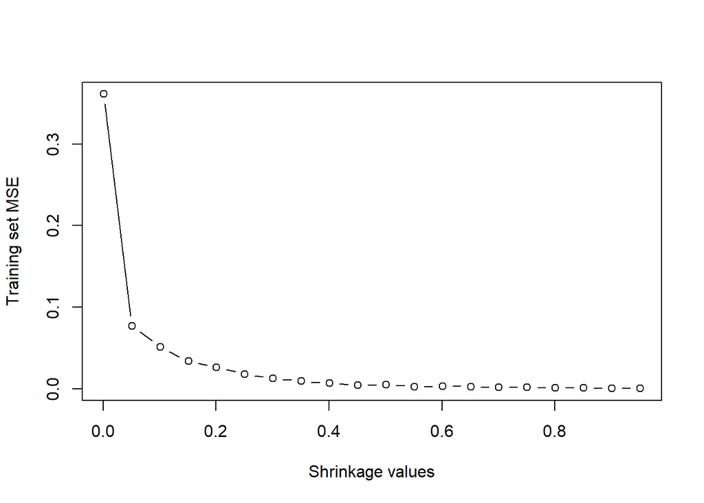

```r
lambda_vals <- seq(from=0.001, to=1, by=0.05)
train_error <- rep(NA, length(lambda_vals))
for (l in 1:length(lambda_vals)) {
  boost_Hitt <- gbm(Salary~.,
                  data=train_Hit,
                  distribution = "gaussian",
                  n.trees = 1000,
                  shrinkage=lambda_vals[l])
  train_predict <- predict(boost_Hitt, train_Hit, n.trees=1000)
  train_error[l] <- mean((train_predict- train_Hit$Salary)^2)
}

plot(lambda_vals, train_error, type="b", xlab="Shrinkage values", ylab="Training set MSE")
```

```r
which.min(train_error)
```

```
## [1] 19
```

```r
train_error[20]
```

```
## [1] 0.0009279427
```

```r
lambda_vals[20]
```

```
## [1] 0.951
```

4. Tạo một biểu đồ với `x-axis` là các giá trị $\lambda$ khác nhau và `y-axis` là `test set MSE` tương ứng.

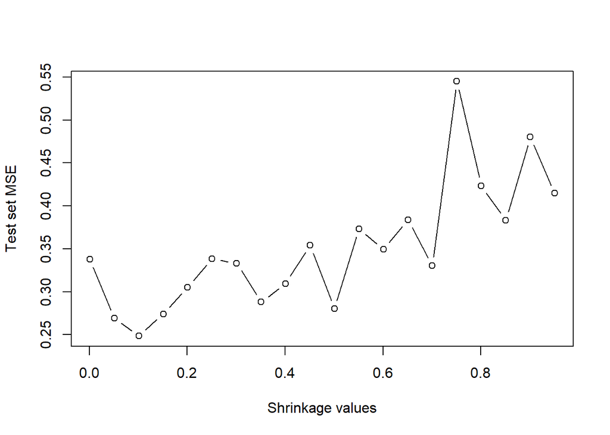

```r
# Viết mã R của bạn ở đây
lambda_vals <- seq(from=0.001, to=1, by=0.05)
test_error <- rep(NA, length(lambda_vals))
for (l in 1:length(lambda_vals)) {
  boost_Hitt <- gbm(Salary~.,
                  data=train_Hit,
                  distribution = "gaussian",
                  n.trees = 1000,
                  shrinkage=lambda_vals[l])
  test_predict <- predict(boost_Hitt, test_Hit, n.trees=1000)
  test_error[l] <- mean((test_predict - test_Hit$Salary)^2)
}


plot(lambda_vals, test_error, type="b", xlab="Shrinkage values", ylab="Test set MSE")
```

```r
which.min(test_error)
```

```
## [1] 3
```

```r
test_error[2]
```

```
## [1] 0.2694168
```

```r
lambda_vals[2]
```

```
## [1] 0.051
```

5. Cho biết biến nào là biến quan trọng nhất trong `boosted model`?

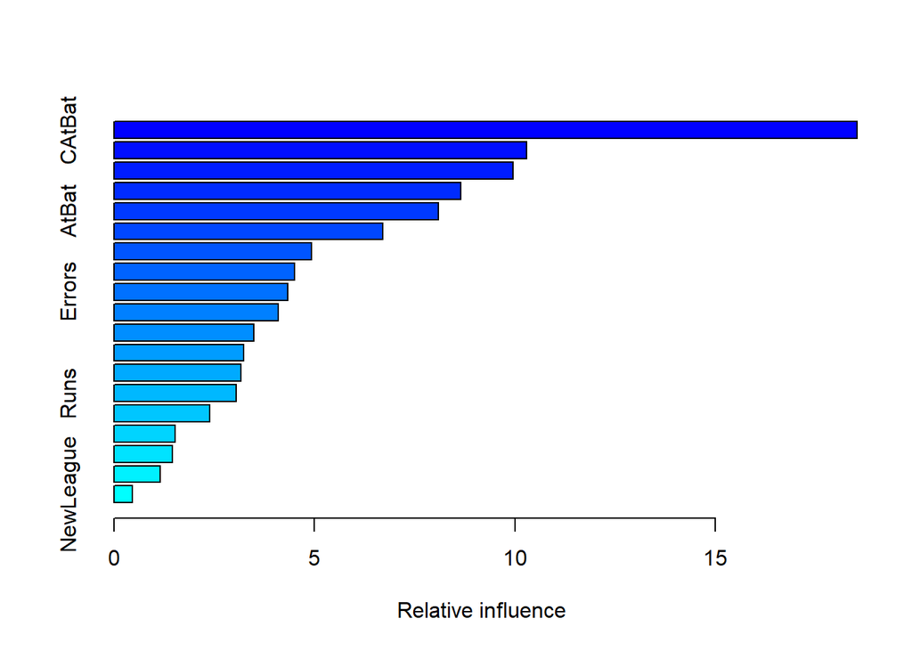

```
##                 var    rel.inf
## CAtBat       CAtBat 18.5346585
## PutOuts     PutOuts 10.2863020
## Assists     Assists  9.9544295
## Walks         Walks  8.6434941
## AtBat         AtBat  8.0868947
## Hits           Hits  6.7049605
## HmRun         HmRun  4.9350798
## CHmRun       CHmRun  4.5122826
## Errors       Errors  4.3359224
## CWalks       CWalks  4.0974935
## CRBI           CRBI  3.4834777
## CRuns         CRuns  3.2268863
## RBI             RBI  3.1703876
## Runs           Runs  3.0464151
## CHits         CHits  2.3930755
## League       League  1.5243476
## Years         Years  1.4582750
## Division   Division  1.1445773
## NewLeague NewLeague  0.4610401
```

```r
# Viết mã R của bạn ở đây
summary(boost_Hitt)
```

Biến quan trọng nhất trong boost model là CAtBat.

6. Áp dụng `bagging` và `random forest` trên `training set` với các tham số mà bạn cho là tốt nhất. So sánh `test MSE` của `boosting` với `test MSE` của `random forest` và `bagging`.

```r
# Viết mã R của bạn ở đây
require(randomForest)

bag.Hit <- randomForest(Salary ~ .,
                        data=train_Hit,
                        mtry=19,
                        importance=TRUE,
                        n.trees=1000)

bag.pred <- predict(bag.Hit, newdata=test_Hit)
mean((bag.pred-test_Hit$Salary)^2)
```

```
## [1] 0.2266313
```

```r
# Viết mã R của bạn ở đây
require(randomForest)
rf.Hit <- randomForest(Salary ~., data=train_Hit, mtry=10, importance=TRUE)
```

```r
ypredict.Hit <- predict(rf.Hit, newdata=test_Hit)
mean((ypredict.Hit-test_Hit$Salary)^2)
```

```
## [1] 0.2209134
```